# Bayesian SITAR model - Univariate fit

## Model summary

Summary of **sitar** model fit

```
SITAR nonlinear mixed-effects model fit by maximum likelihood
  Call: sitar::sitar(x = age, y = height, id = id, data = data, df = 5)
  Log-likelihood: -1064.769
  Fixed: s1 + s2 + s3 + s4 + s5 + a + b + c ~ 1
         s1          s2          s3          s4          s5           a           b
 23.9049987  27.1749944  25.7713523  37.4373413  23.7227203 137.3389224   0.5411769
          c
  0.2805348

Random effects:
 Formula: list(a ~ 1, b ~ 1, c ~ 1)
 Level: id
 Structure: General positive-definite, Log-Cholesky parametrization
         StdDev    Corr
a        5.8747751 a      b
b        1.0039002  0.073
c        0.1242043  0.323 -0.774
Residual 0.4722997

Number of Observations: 770
Number of Groups: 70
```

Summary of the **bsitar** model fit

```
 Family: gaussian
  Links: mu = identity; sigma = identity
Formula: height ~ SITARFun(age, a, b, c, s1, s2, s3, s4, s5)
         a ~ 1 + (1 | 1 | gr(id, dist = "gaussian"))
         b ~ 1 + (1 | 1 | gr(id, dist = "gaussian"))
         c ~ 1 + (1 | 1 | gr(id, dist = "gaussian"))
         s1 ~ 1
         s2 ~ 1
         s3 ~ 1
         s4 ~ 1
         s5 ~ 1
   Data: structure(list(id = structure(c(1L, 1L, 1L, 1L, 1L (Number of observations: 770)
  Draws: 2 chains, each with iter = 1000; warmup = 500; thin = 7;
         total post-warmup draws = 143

Multilevel Hyperparameters:
~id (Number of levels: 70)
                             Estimate Est.Error l-95% CI u-95% CI Rhat Bulk_ESS Tail_ESS
sd(a_Intercept)                  6.12      0.52     5.18     7.34 1.01       75      106
sd(b_Intercept)                  1.02      0.09     0.85     1.22 1.01      127       81
sd(c_Intercept)                  0.13      0.01     0.11     0.15 1.03      124      130
cor(a_Intercept,b_Intercept)     0.10      0.11    -0.10     0.33 1.01      126      114
cor(a_Intercept,c_Intercept)     0.31      0.10     0.11     0.49 1.01      140       77
cor(b_Intercept,c_Intercept)    -0.75      0.05    -0.83    -0.64 0.99      179      170

Regression Coefficients:
             Estimate Est.Error l-95% CI u-95% CI Rhat Bulk_ESS Tail_ESS
a_Intercept    137.20      1.13   135.28   139.44 1.05       41       73
b_Intercept      0.53      0.15     0.25     0.81 1.01       83       81
c_Intercept      0.29      0.06     0.18     0.40 0.99      147      127
s1_Intercept     4.31      0.24     3.86     4.75 0.99      146      124
s2_Intercept     8.20      0.46     7.38     9.13 1.00      119      106
s3_Intercept   -41.57      3.39   -47.74   -35.14 0.99      142      106
s4_Intercept    52.27      6.32    40.31    63.62 0.99      160      135
s5_Intercept   -16.73      4.37   -23.63    -7.68 0.99      162      135

Further Distributional Parameters:
      Estimate Est.Error l-95% CI u-95% CI Rhat Bulk_ESS Tail_ESS
sigma     0.47      0.01     0.45     0.50 1.00      182      126

Draws were sampled using sampling(NUTS). For each parameter, Bulk_ESS
and Tail_ESS are effective sample size measures, and Rhat is the potential
scale reduction factor on split chains (at convergence, Rhat = 1).
```

Figure below shows a comparison of observed growth curves with those adjusted via the random effects. As described earlier (see Introduction), the random effects align individual-specific growth trajectories towards a common population average (mean) trajectory. The three growth patterns that *SITAR* adjust via random effects are size, timing and intensity:

- Size is an individual’s mean height compared to the average (measured in cm)
- Timing is the individual’s age at peak height velocity (i.e. the age when they are growing fastest) compared to the average (measured in years)
- Intensity is their growth rate compared to the average (measured as a fraction, or percentage / 100)

Adjusted curves aligned with the mean curve (Figure shown below) indicate that most of the inter-individual variability has been captured. This is achieved by: 1) shifting the high curves down and the low curves up to adjust for the size, 2) shifting the early curves later and the late curves earlier (translation) to adjust for the timing, and 3) steep curves are made shallower by stretching them along the age scale whereas shallow curves are made steeper by shrinking them along the age scale (rotation) to adjust for the intensity. This explains the name SITAR - Super Imposition by Translation And Rotation. The curve adjustment involves translation (shifting the curves up/down and left/right) and rotation (making them steeper or shallower), and the effect is to superimpose the curves. The complexity of the spline curve’s shape is determined by the degrees of freedom (`df`) argument in the **sitar** and **bsitar** call. In our example, the models are fit using five degrees of freedom.

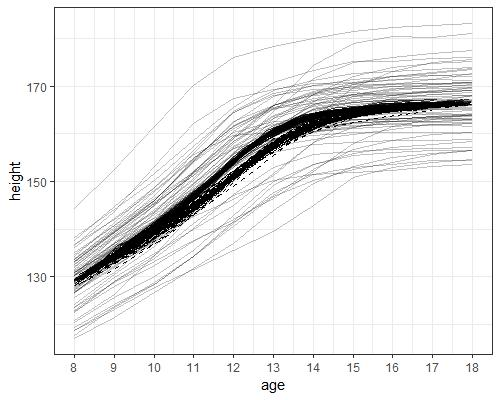

Observed curves along with the superimposed adjusted curves (via random effects) for the **sitar** and **bsitar** models. The observed curves are shown as solid light grey lines whereas the adjusted curves for the **sitar** model are displayed as solid black lines. The adjusted curves for the **bsitar** model are shown as dotted black lines.

## Random effects (size, timing and intensity)

The effect of *SITAR* adjustment in individual curves via random effects is shown more clearly in Figure below which displays observed and adjusted curves for tallest and shortest individuals along with the population average (mean) curve. The corresponding estimates of random effects (size, timing and intensity) are provided in the Tables below. Note that intensity c, multiplied by 100, is a percentage. Results for both the models are very similar to each other. Results for the **sitar** model are presented below.

For a broader comparison among the **sitar** and **bsitar** models, random effects for the first ten individuals estimated are shown below (see Tables). The association (correlation) between random effects (across all individuals) is shown as a scatterplot in Figures and corresponding estimates are provided in Tables. Results show that timing is negatively correlated with intensity indicating the early puberty is associated with faster growth.

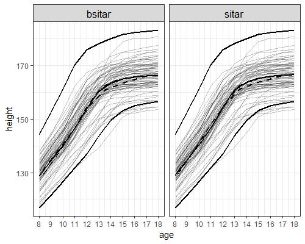

Observed and adjusted curve (via random effects) curves along with the population averag curves for **sitar** and **bsitar** models. The observed curves for all individuals are shown as solid light grey lines whereas curves for the tallest and shortest individuals are displayed using the solid black lines. The adjusted curves for the tallest and shortest individuals are shown as dotted black lines, and the population average curve is shown as solid black line.

Random effects for the tallest and shortest individual for the **sitar** model

| id | a | b | c |
| --- | --- | --- | --- |
| 310 | 14.90 | -1.42 | 0.26 |
| 355 | -9.47 | 1.42 | -0.15 |

a: Size (height); b: Timing (age at peak growth velocity, APGV); c: Intensity (peak growth velocity, AGV)

Random effects for the tallest and shortest individual for the **bsitar** model

| id | a | b | c |
| --- | --- | --- | --- |
| 310 | 15.03 | -1.42 | 0.26 |
| 355 | -9.36 | 1.40 | -0.15 |

a: Size (height); b: Timing (age at peak growth velocity, APGV); c: Intensity (peak growth velocity, AGV)

Random effects estimates for the first ten individuals (**sitar** model)

| id | a | b | c |
| --- | --- | --- | --- |
| 301 | -7.67 | -0.99 | -0.01 |
| 302 | -0.25 | 0.19 | -0.04 |
| 303 | -4.82 | -2.06 | 0.08 |
| 304 | 1.48 | 0.18 | -0.07 |
| 305 | 4.32 | 0.73 | -0.05 |
| 306 | -1.86 | -0.07 | 0.10 |
| 307 | 0.84 | -0.13 | 0.04 |
| 308 | -1.08 | 2.53 | -0.25 |
| 309 | -2.73 | 0.32 | -0.09 |
| 310 | 14.90 | -1.42 | 0.26 |

a: Size (height); b: Timing (age at peak growth velocity, APGV); c: Intensity (peak growth velocity, AGV)

Random effects estimates for the first ten individuals (**bsitar** model)

| id | a | b | c |
| --- | --- | --- | --- |
| 301 | -7.53 | -1.00 | -0.01 |
| 302 | -0.10 | 0.18 | -0.04 |
| 303 | -4.70 | -2.06 | 0.08 |
| 304 | 1.63 | 0.16 | -0.06 |
| 305 | 4.45 | 0.71 | -0.05 |
| 306 | -1.75 | -0.09 | 0.10 |
| 307 | 0.95 | -0.13 | 0.04 |
| 308 | -0.96 | 2.51 | -0.24 |
| 309 | -2.59 | 0.30 | -0.08 |
| 310 | 15.03 | -1.42 | 0.26 |

a: Size (height); b: Timing (age at peak growth velocity, APGV); c: Intensity (peak growth velocity, AGV)

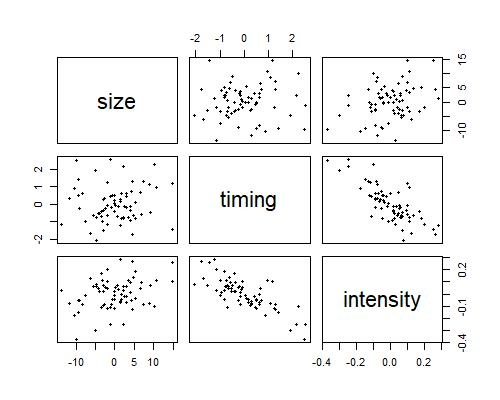

Correlation scatterplot of random effects for the **sitar** model

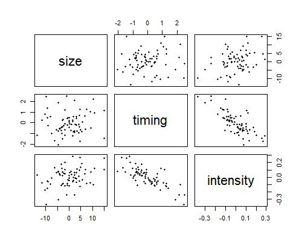

Correlation scatterplot of random effects for the **bsitar** model

Correlation estimates for the random effects (**sitar** model)

| a | b | c |
| --- | --- | --- |
| 1.00 | 0.07 | 0.33 |
| 0.07 | 1.00 | -0.78 |
| 0.33 | -0.78 | 1.00 |

a: Size (height); b: Timing (age at peak growth velocity, APGV); c: Intensity (peak growth velocity, AGV)

Correlation estimates for the random effects (**bsitar** model)

| a | b | c |
| --- | --- | --- |
| 1.00 | 0.07 | 0.33 |
| 0.07 | 1.00 | -0.77 |
| 0.33 | -0.77 | 1.00 |

a: Size (height); b: Timing (age at peak growth velocity, APGV); c: Intensity (peak growth velocity, AGV)

## Growth curves (distance and velocity)

### Population average (mean) distance and velocity curves

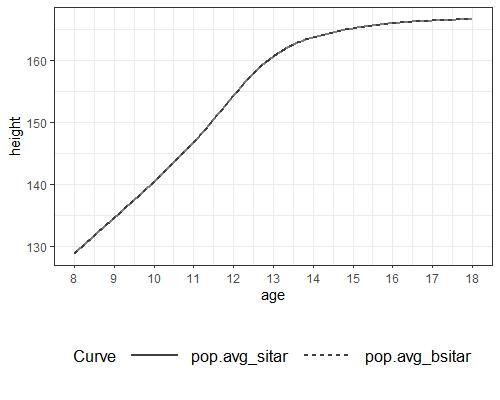

Population average distance curves for the **sitar** and **bsitar** models

Estimated distance curve (see Figure below) shows that increase in height follows a sigmoid pattern with maximum gain in height occurring around 12 years of age. This is confirmed by the velocity curve shown in Figure (below) which shows a clear spurt in growth rate which peaks at around 11.7 years of age (see Population average (mean) estimates.

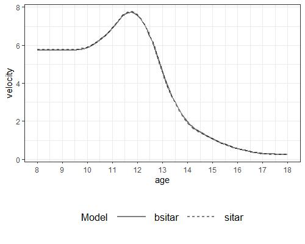

Population average velocity curves for the **sitar** and **bsitar** models

### Individual specific distance and velocity curves

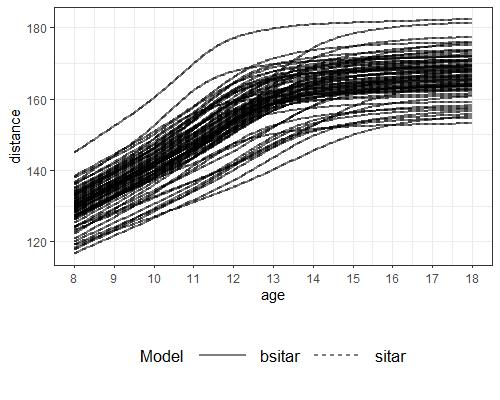

Individual specific distance curves for the **sitar** and **bsitar** models

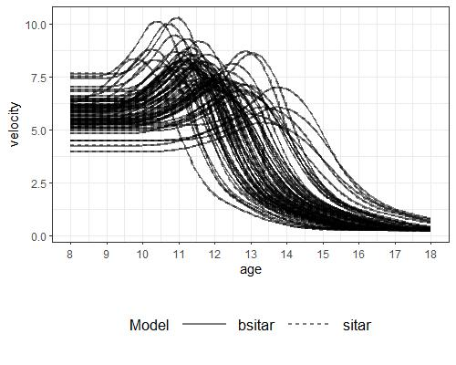

Individual specific velocity curves for the **sitar** and **bsitar** models

Individual specific distance and velocity curves (shown below) follow a pattern similar to the population average distance and velocity curves described earlier. Individual velocity curves (shown below) show that all individuals experience a pubertal growth spurt but the timing of the spurt varies between 10 and 14 years with varying growth pattern among individuals. Some individuals are consistently taller than average and others consistently shorter. While some start relatively short and become taller, others have opposite growth pattern i.e., they are taller at an early age and achieve less height in later years as compared to those who were short at an early age.

## Growth parameters (timing and intensity)

### Population average (mean) estimates

As velocity curves estimated by the **sitar** and **bsitar** models are very similar to each other (see below), it is not surprising that both models provide almost identical estimates for the timing (i.e., age at peak growth velocity, APGV) and the intensity (i.e.,peak growth velocity, PGV) of the growth spurt (see Table below).

Population average timing and intensity estimates for the **sitar** and **bsitar** models

| Parameter | bsitar | sitar |
| --- | --- | --- |
| APGV | 11.72 | 11.71 |
| PGV | 7.73 | 7.76 |

APGV: age at peak growth velocity; PGV: peak growth velocity

### Individual specific estimates

Like population average, both **sitar** and **bsitar** models provide very similar estimates for the timing (APGV) and the intensity (PGV) of the growth spurt (see Tables below).

Individual specific timing and intensity estimates for the first ten individuals (**sitar** model)

| id | APGV | PGV |
| --- | --- | --- |
| 301 | 10.70 | 7.68 |
| 302 | 11.82 | 7.45 |
| 303 | 9.80 | 8.41 |
| 304 | 11.77 | 7.27 |
| 305 | 12.34 | 7.36 |
| 306 | 11.82 | 8.58 |
| 307 | 11.66 | 8.06 |
| 308 | 13.74 | 6.07 |
| 309 | 11.87 | 7.12 |
| 310 | 10.70 | 10.03 |

APGV: age at peak growth velocity; PGV: peak growth velocity

Individual specific timing and intensity estimates for the first ten individuals (**bsitar** model)

| id | APGV | PGV |
| --- | --- | --- |
| 301 | 10.70 | 7.66 |
| 302 | 11.82 | 7.44 |
| 303 | 9.79 | 8.36 |
| 304 | 11.76 | 7.28 |
| 305 | 12.33 | 7.36 |
| 306 | 11.80 | 8.57 |
| 307 | 11.65 | 8.04 |
| 308 | 13.73 | 6.07 |
| 309 | 11.86 | 7.13 |
| 310 | 10.70 | 10.02 |

APGV: age at peak growth velocity; PGV: peak growth velocity

## References

Cole, T. (2022). *Sitar: Super imposition by translation and rotation growth curve analysis*. https://CRAN.R-project.org/package=sitar

Cole, T. J., Donaldson, M. D. C., & Ben-Shlomo, Y. (2010). SITAR—a useful instrument for growth curve analysis. *International Journal of Epidemiology*, *39*(6), 1558–1566. https://doi.org/10.1093/ije/dyq115

Sandhu, S. (2023). *Bsitar: Bayesian super imposition by translation and rotation growth curve analysis*. https://CRAN.R-project.org/package=bsitar